# Mercator dissolved oxygen and temperature validation

Author

Emily Nazario

Published

July 1, 2024

On this document I compare the mean Mercator BIORYS4 and GLORYS4 dissolved oxygen (DO) and temperature (temp) data to values from climatology products (DO: World Ocean Atlas and CSIRO; temp: OISST (at 0m), CSIRO, and WOA) and CalCOFI stations. DO and temp values will be compared to the climatology products as averages across the study area (lat: 1 to 49 and lon: -153 to -104) at 0m and at 200m depth which represent two of the depth layers I will use for the shark models.

## DO (mmol/L) at 0m

### Mean across study period (2003-2015)

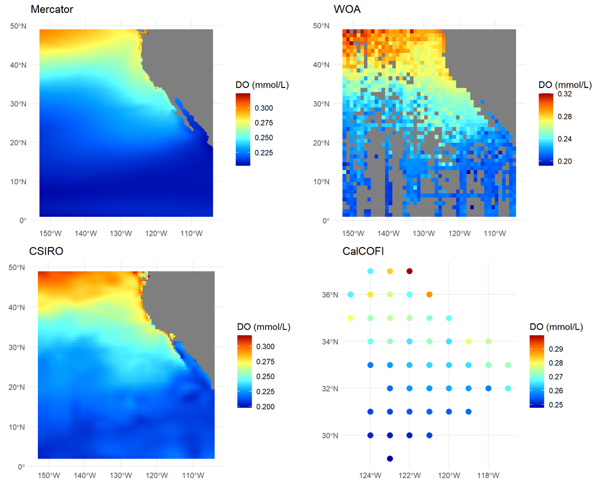

### Mercator difference plots

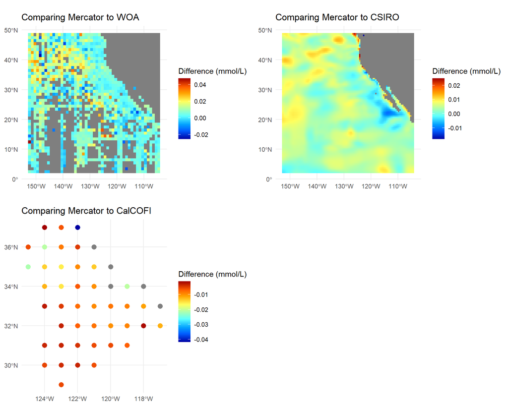

### Mercator temporal variation vs. CalCOFI data 0m

Here, the mercator dissolved oxygen rasters were subset the month-day-year that a CalCOFI bottle sample was collected. The plotted mercator values represent the closest grid cell to that CalCOFI station when a sample was collected. A daily temporal resolution was possible here.

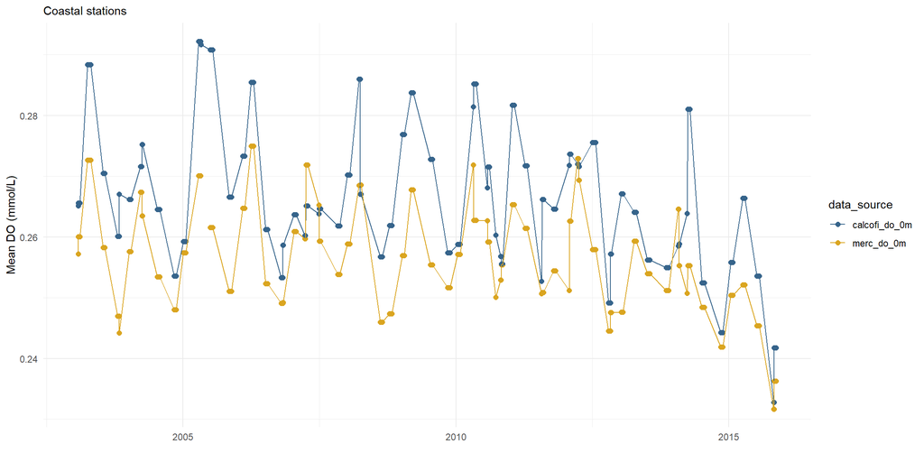

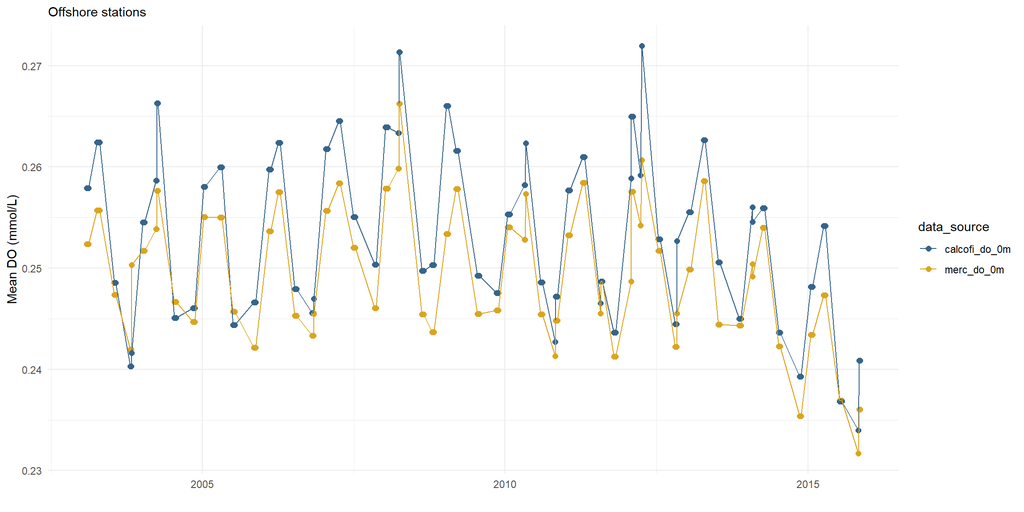

## DO (mmol/L) at 200m

### Mean across study period (2003-2015)

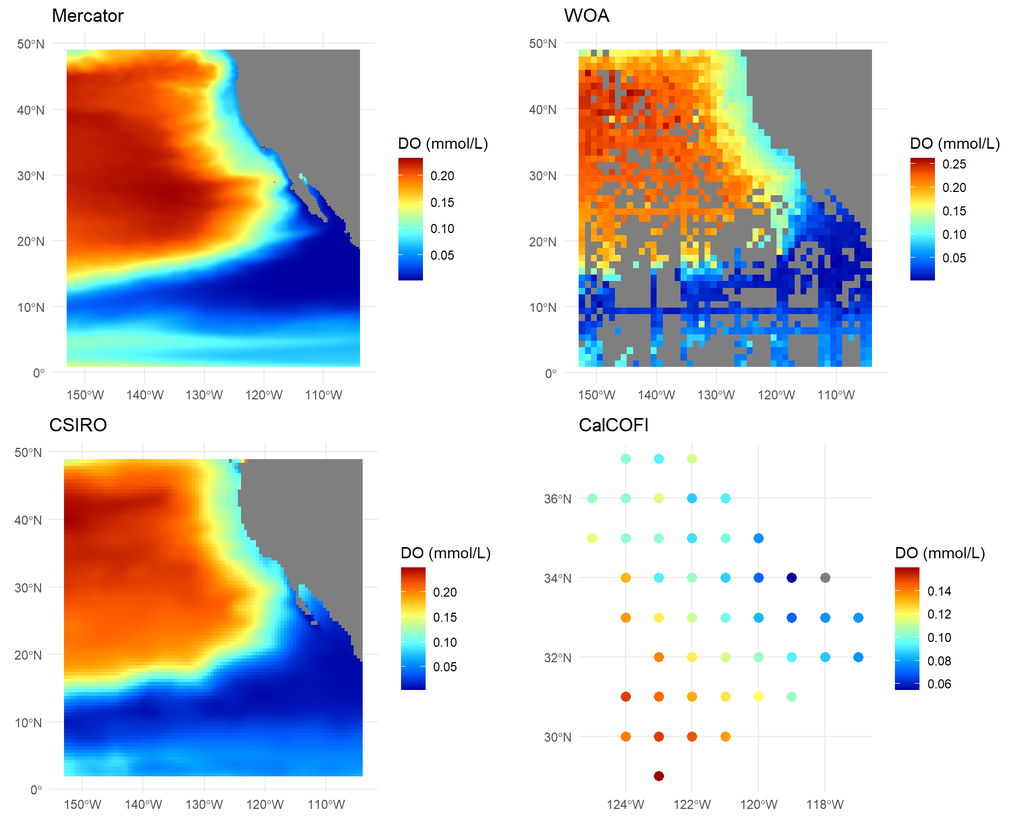

### Mercator difference plots

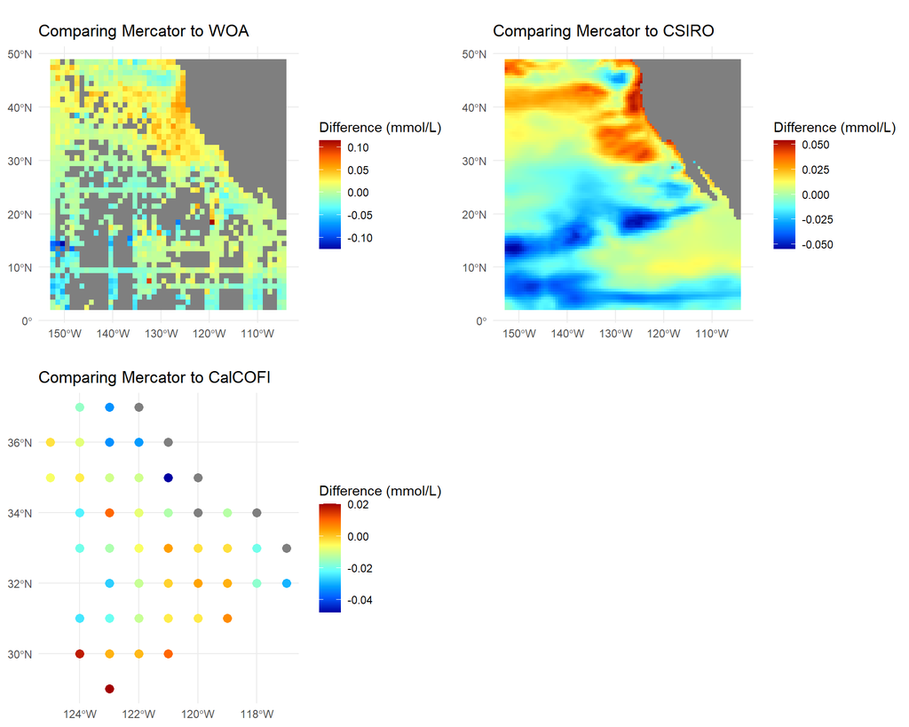

### Mercator temporal variation vs. CalCOFI data 200m

Here, the mercator dissolved oxygen rasters were subset the month-day-year that a CalCOFI bottle sample was collected. The plotted mercator values represent the closest grid cell to that CalCOFI station when a sample was collected. A daily temporal resolution was possible here.

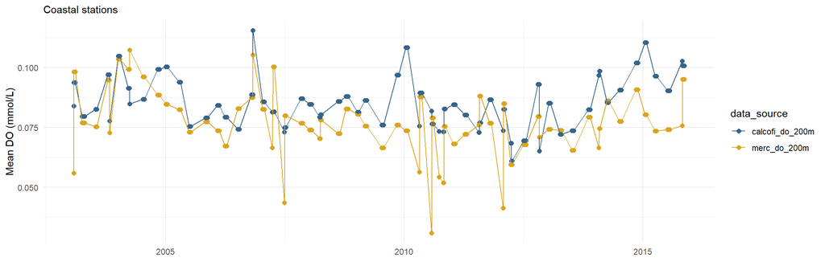

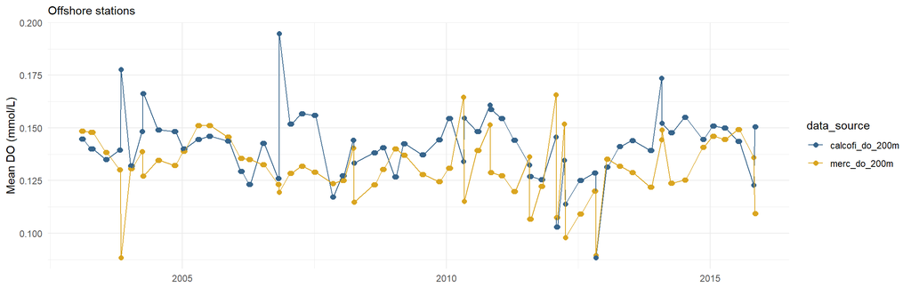

## Temp (C) at 0m

### Mean across study period (2003-2015)

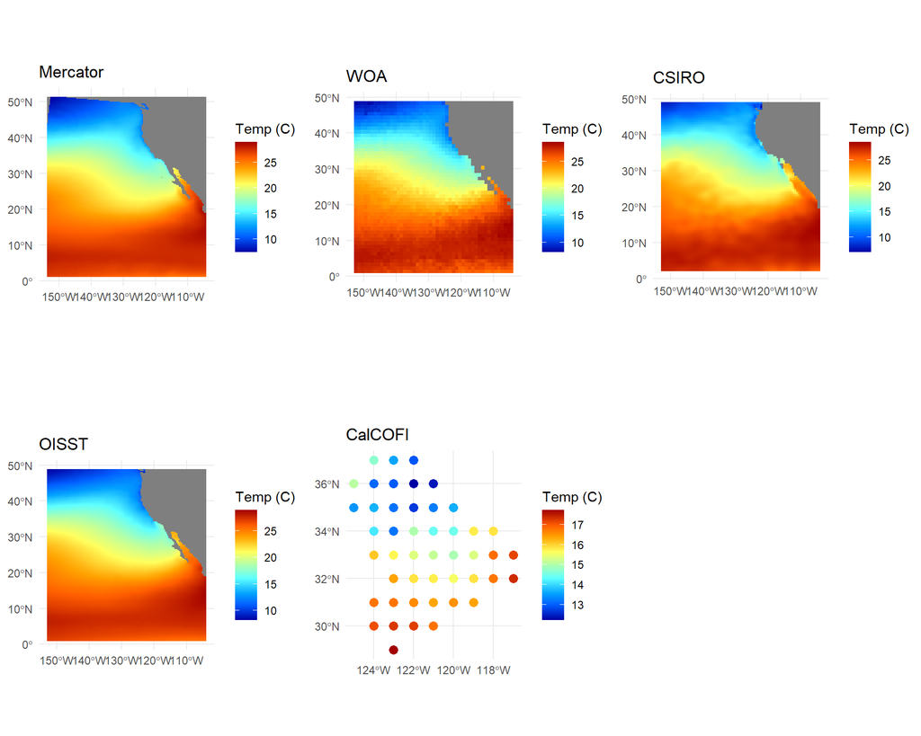

### Mercator difference plots

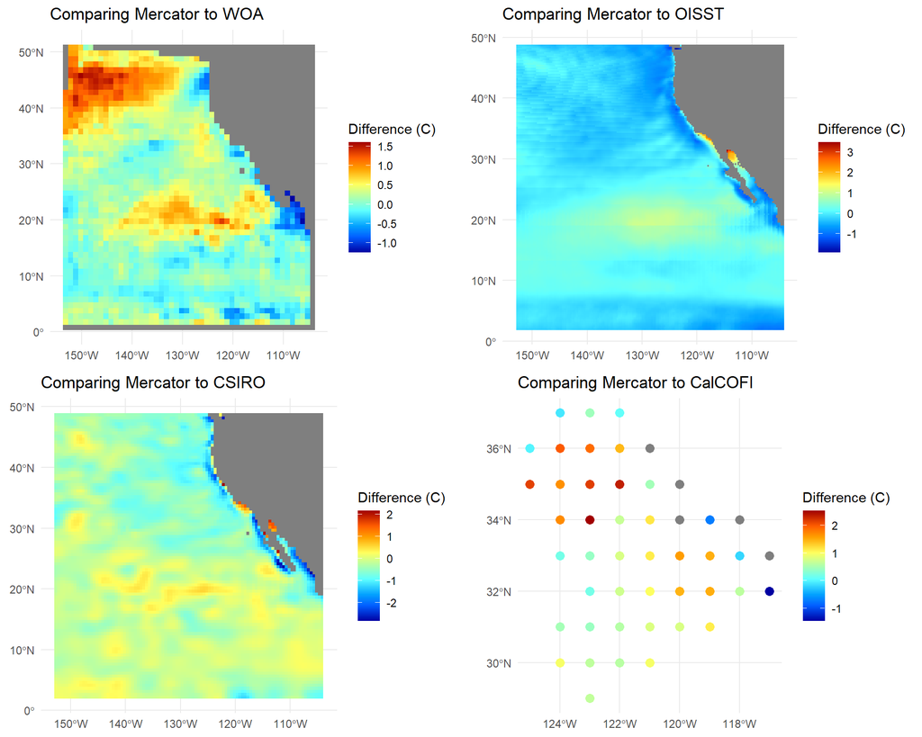

### Mercator temporal variation vs. CalCOFI data 0m

Here, the mercator temperature rasters were subset the month-year that a CalCOFI bottle sample was collected. The plotted mercator values represent the closest grid cell to that CalCOFI station when a sample was collected. A monthly temporal resolution was possible here and not daily due to computational power of extracting the mercator temperature data directly from mercator rather than Copernicus, which is how the dissolved oxygen rasters were obtained.

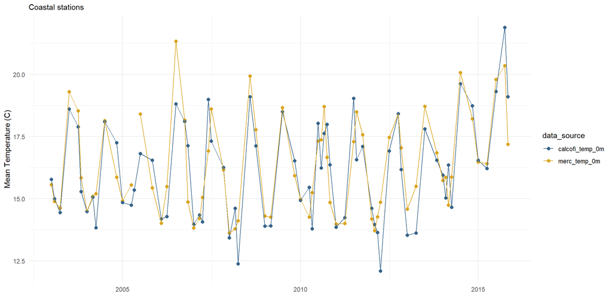

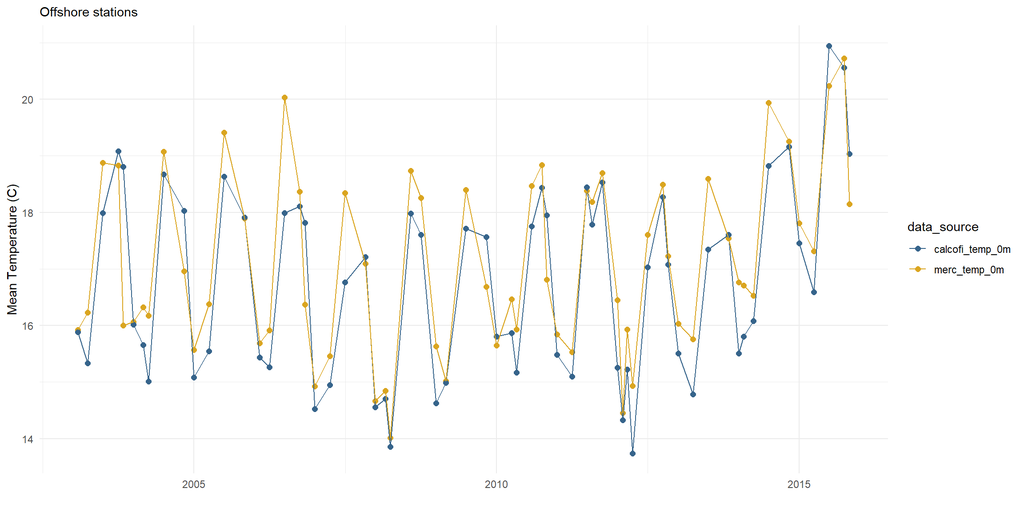

## Temp (C) at 200m

### Mean across study period (2003-2015)

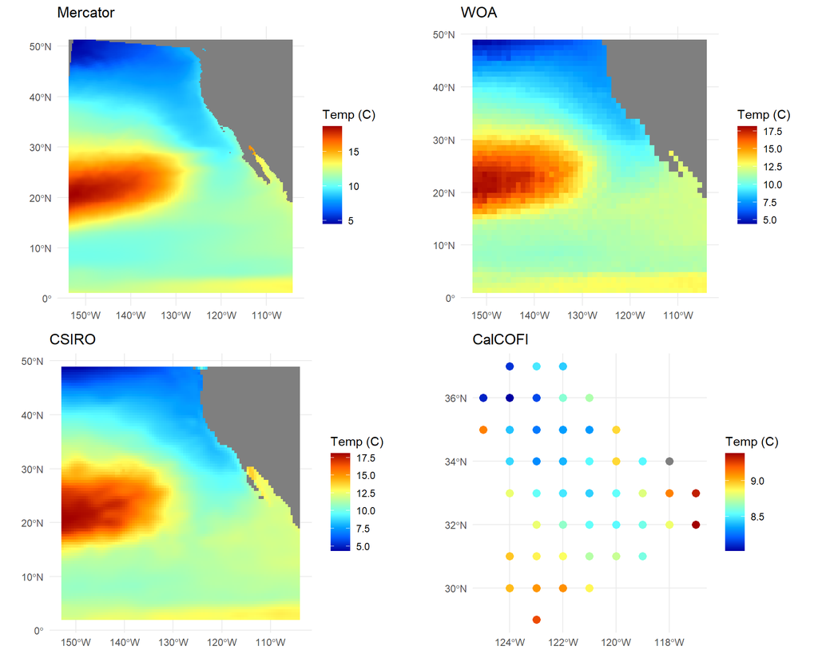

### Mercator difference plots

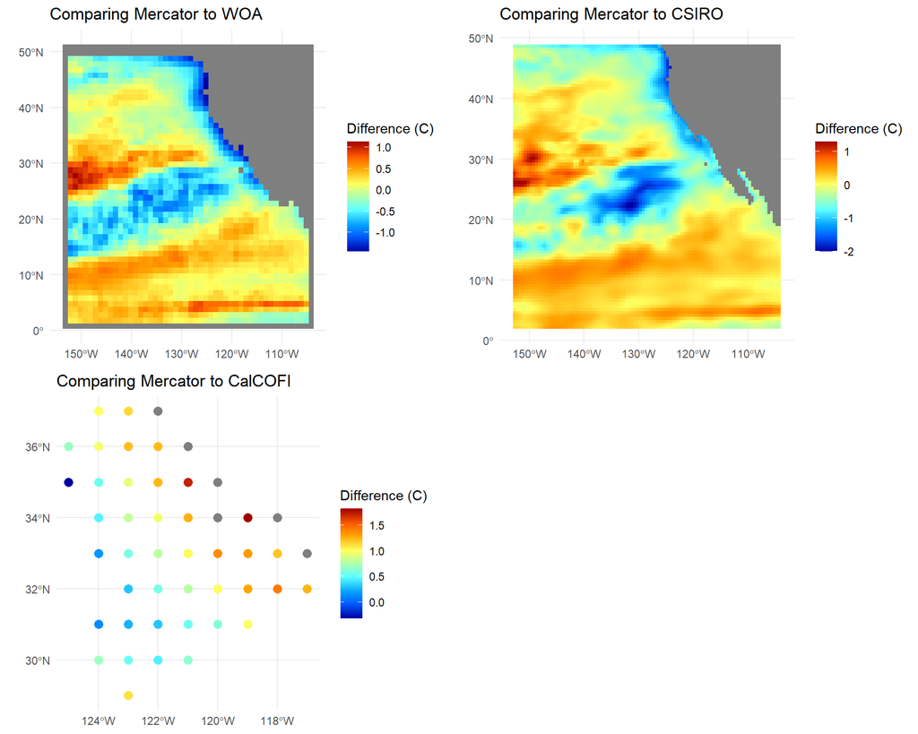

### Mercator temporal variation vs. CalCOFI data 200m

Here, the mercator temperature rasters were subset the month-year that a CalCOFI bottle sample was collected. The plotted mercator values represent the closest grid cell to that CalCOFI station when a sample was collected. A monthly temporal resolution was possible here and not daily due to computational power of extracting the mercator temperature data directly from mercator rather than Copernicus, which is how the dissolved oxygen rasters were obtained.

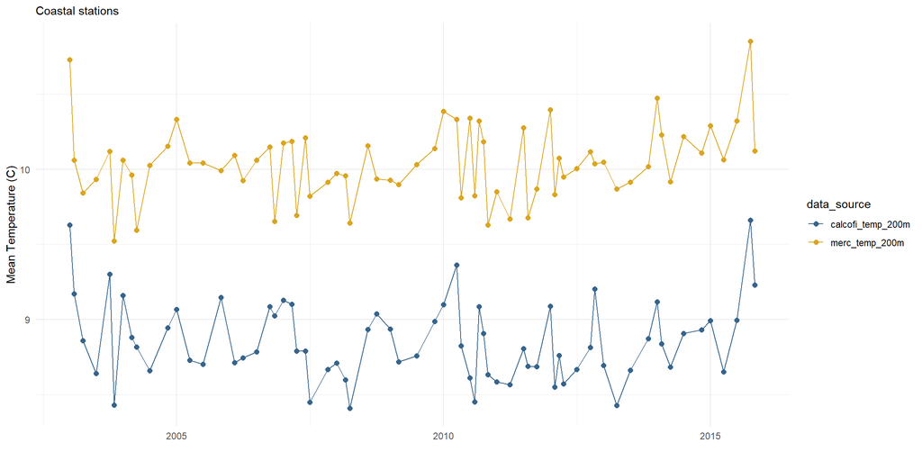

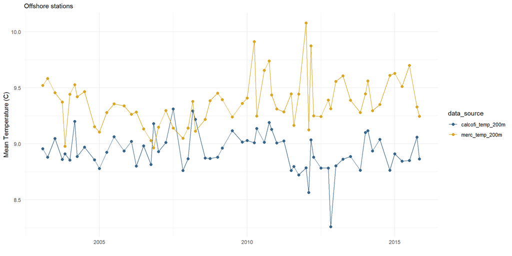